# COM 674

## Dad Joke

When I was a kid we were so poor that we had to share a calculator, and the “X” button didn’t even work.

Times were hard.

## Housekeeping

- Start on data collection now
- The rest of the class
  - Git
  - Stats
  - Screen scraping
  - Additional topics

## Cleaning data

- Why is data ‘dirty’?
  - Errors in transcription
  - Bugs in software that produced it
  - Missing data (e.g., when a date is unknown it’s recoded as Jan 1)
  - Can’t be read by software
    - Wrong date format
    - Multiple age formats - e.g., ‘4’, ‘4 yo’, ‘4 years’
  - Observations that shouldn’t be in the analysis
  - Inappropriate for statistical tests
    - log-transformations
    - Coding groups (e.g., high-risk and low-risk)

## Operationalization

- Making a construct measurable
  - Constructs are not empirical and can’t be tested directly
  - We must argue that our measures represent or at least are correlated with the concepts we really care about
  - Hypotheses relate concepts together, e.g., “socially cohesive groups are more willing to contribute to shared goals”
  - In order to test this, need to argue that you have something that represents social cohesion, and something that represents shared goals.

## Online data

- Online data is “raw”
  - This is generally wonderful - we have actual conversations, full text, etc.
- However, it isn’t made for researchers
  - It isn’t designed to measure a construct
  - We have to do the work to create measures that measure them (and recognize when we can’t)

## HW Review

## Papers

Sara Klingenstein, Tim Hitchcock, and Simon DeDeo. 2014. The civilizing process in London’s Old Baily. Proceedings of the National Academy of Sciences

## How can we detect changes in culture?

- Digitization of historical records allows for comparison across time
  - Google N-gram viewer
  - Censuses
- This paper uses court transcripts from London’s Old Bailey courthouse from 1760s-1910s

## Violent and non-violent offenses are talked about differently

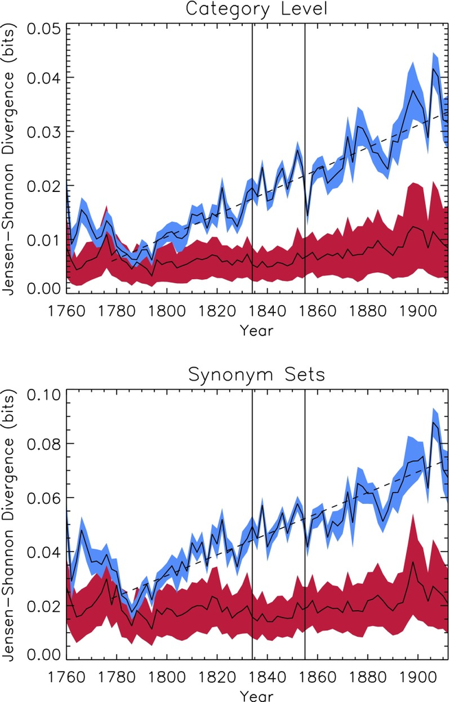

## Some questions

- What are some of the dangers of doing this kind of work?
- What are some computational methods that are becoming “normalized” in your discipline?

## Merton Paper

Merton, Robert K. 1948. The Bearing of Empirical Research upon the Development of Social Theory. American Sociological Review.

## Empirical research for developing theory

- Empirical work doesn’t just verify/test theories
- Serendipity: Something odd in data that needs an explanation
- Recasting: New aspects become more salient
- Refocusing: Advances in procedures lead to attention where things can be measured/tested
- Clarification: Operationalizing concepts requires drawing boundaries around them